# Machine Learning with R and H2O

AgileSoDA 선임연구원 김은지

## 1. h2o Setting, 환경 확인

```r
library(h2o)
# H2O 클라우드 만들기
h2o.init(nthreads = -1)  # -1 : 모든 사용가능한 스레드 사용
```

```
##
## H2O is not running yet, starting it now...
##
## Note:  In case of errors look at the following log files:
##     C:\Users\AGILES~1\AppData\Local\Temp\Rtmpm6VY0s/h2o_AgileSoDA_started_from_r.out
##     C:\Users\AGILES~1\AppData\Local\Temp\Rtmpm6VY0s/h2o_AgileSoDA_started_from_r.err
##
##
## Starting H2O JVM and connecting: . Connection successful!
##
## R is connected to the H2O cluster:
##     H2O cluster uptime:         8 seconds 549 milliseconds
##     H2O cluster timezone:       Asia/Seoul
##     H2O data parsing timezone:  UTC
##     H2O cluster version:        3.20.0.8
##     H2O cluster version age:    1 month and 30 days
##     H2O cluster name:           H2O_started_from_R_AgileSoDA_kmz017
##     H2O cluster total nodes:    1
##     H2O cluster total memory:   0.85 GB
##     H2O cluster total cores:    4
##     H2O cluster allowed cores:  4
##     H2O cluster healthy:        TRUE
##     H2O Connection ip:          localhost
##     H2O Connection port:        54321
##     H2O Connection proxy:       NA
##     H2O Internal Security:      FALSE
##     H2O API Extensions:         Algos, AutoML, Core V3, Core V4
##     R Version:                  R version 3.5.1 (2018-07-02)
```

```r
h2o.removeAll()          # 현재 돌아가고 있는 클러스터가 있다면 모두 지움
```

```
## [1] 0
```

- cluster의 이름, 버전, 사용 가능한 메모리, 환경 등에 대한 정보가 출력된다.

## 2. Demo : GLM

아래와 같은 작업 실습  
* import a file  
* Define significant data  
* View data  
* Create testing and training sets using sampling

```r
airlinesURL = "https://s3.amazonaws.com/h2o-airlines-unpacked/allyears2k.csv"
# file 불러오기
airlines.hex = h2o.importFile(path = airlinesURL, destination_frame = "airlines.hex")
# destination_file : h2o cluster 내에서의 데이터 명 지정

summary(airlines.hex)
```

```
##  Year           Month            DayofMonth     DayOfWeek
##  Min.   :1987   Min.   : 1.000   Min.   : 1.0   Min.   :1.000
##  1st Qu.:1992   1st Qu.: 1.000   1st Qu.: 6.0   1st Qu.:2.000
##  Median :1998   Median : 1.000   Median :14.0   Median :4.000
##  Mean   :1998   Mean   : 1.409   Mean   :14.6   Mean   :3.821
##  3rd Qu.:2003   3rd Qu.: 1.000   3rd Qu.:23.0   3rd Qu.:5.000
##  Max.   :2008   Max.   :10.000   Max.   :31.0   Max.   :7.000
##
##  DepTime          CRSDepTime       ArrTime        CRSArrTime
##  Min.   :   1.0   Min.   :   0.0   Min.   :   1   Min.   :   0
##  1st Qu.: 927.4   1st Qu.: 908.6   1st Qu.:1117   1st Qu.:1107
##  Median :1328.2   Median :1319.2   Median :1525   Median :1515
##  Mean   :1345.8   Mean   :1313.2   Mean   :1505   Mean   :1485
##  3rd Qu.:1733.8   3rd Qu.:1718.1   3rd Qu.:1916   3rd Qu.:1902
##  Max.   :2400.0   Max.   :2359.0   Max.   :2400   Max.   :2359
##  NA's   :1086                      NA's   :1195
##  UniqueCarrier FlightNum        TailNum                 ActualElapsedTime
##  US:18729      Min.   :   1.0   UNKNOW          :  179  Min.   : 16.0
##  UA: 9434      1st Qu.: 202.4   000000          :  124  1st Qu.: 71.0
##  WN: 6170      Median : 553.9   <0xE4>NKNO<0xE6>:  114  Median :101.0
##  HP: 3451      Mean   : 818.8   0               :   66  Mean   :124.8
##  PS: 3212      3rd Qu.:1241.0   N912UA          :   59  3rd Qu.:151.0
##  DL:  935      Max.   :3949.0   N316AW          :   56  Max.   :475.0
##                                 NA              :16024  NA's   :1195
##  CRSElapsedTime AirTime         ArrDelay          DepDelay
##  Min.   : 17    Min.   : 14.0   Min.   :-63.000   Min.   :-16.00
##  1st Qu.: 71    1st Qu.: 61.0   1st Qu.: -6.000   1st Qu.: -2.00
##  Median :102    Median : 91.0   Median :  2.000   Median :  1.00
##  Mean   :125    Mean   :114.3   Mean   :  9.317   Mean   : 10.01
##  3rd Qu.:151    3rd Qu.:140.0   3rd Qu.: 14.000   3rd Qu.: 10.00
##  Max.   :437    Max.   :402.0   Max.   :475.000   Max.   :473.00
##  NA's   :13     NA's   :16649   NA's   :1195      NA's   :1086
##  Origin    Dest      Distance         TaxiIn            TaxiOut
##  DEN:3558  PHX:9317  Min.   :  11.0   Min.   :  0.000   Min.   :  0.00
##  PIT:3241  PHL:4482  1st Qu.: 323.0   1st Qu.:  3.000   1st Qu.:  9.00
##  ORD:2246  PIT:3020  Median : 537.7   Median :  5.000   Median : 12.00
##  BUR:2021  ORD:2103  Mean   : 730.2   Mean   :  5.381   Mean   : 14.17
##  CLT:1781  CLT:1542  3rd Qu.: 916.9   3rd Qu.:  6.000   3rd Qu.: 16.00
##  PHL:1632  DEN:1470  Max.   :3365.0   Max.   :128.000   Max.   :254.00
##                      NA's   :35       NA's   :16026     NA's   :16024
```

[output cut: 9 more lines]

```
##  Min.   :  0.0000   Min.   :  0.000   Min.   : 0.00000   Min.   :  0.00
##  1st Qu.:  0.0000   1st Qu.:  0.000   1st Qu.: 0.00000   1st Qu.:  0.00
##  Median :  0.0000   Median :  0.000   Median : 0.00000   Median :  0.00
##  Mean   :  0.2894   Mean   :  4.855   Mean   : 0.01702   Mean   :  7.62
##  3rd Qu.:  0.0000   3rd Qu.:  0.000   3rd Qu.: 0.00000   3rd Qu.:  0.00
##  Max.   :201.0000   Max.   :323.000   Max.   :14.00000   Max.   :373.00
##  NA's   :35045      NA's   :35045     NA's   :35045      NA's   :35045
##  IsArrDelayed IsDepDelayed
##  YES:24441    YES:23091
##  NO :19537    NO :20887
##
##
##
##
##
```

```r
str(airlines.hex)
```

```
## Class 'H2OFrame' <environment: 0x000000001a40d280>
##  - attr(*, "op")= chr "Parse"
##  - attr(*, "id")= chr "airlines.hex"
##  - attr(*, "eval")= logi FALSE
##  - attr(*, "nrow")= int 43978
##  - attr(*, "ncol")= int 31
##  - attr(*, "types")=List of 31
##   ..$ : chr "int"
##   ..$ : chr "int"
##   ..$ : chr "int"
##   ..$ : chr "int"
##   ..$ : chr "int"
##   ..$ : chr "int"
##   ..$ : chr "int"
##   ..$ : chr "int"
##   ..$ : chr "enum"
##   ..$ : chr "int"
##   ..$ : chr "enum"
##   ..$ : chr "int"
##   ..$ : chr "int"
##   ..$ : chr "int"
##   ..$ : chr "int"
##   ..$ : chr "int"
##   ..$ : chr "enum"
##   ..$ : chr "enum"
##   ..$ : chr "int"
##   ..$ : chr "int"
##   ..$ : chr "int"
##   ..$ : chr "int"
##   ..$ : chr "enum"
##   ..$ : chr "int"
##   ..$ : chr "int"
##   ..$ : chr "int"
##   ..$ : chr "int"
##   ..$ : chr "int"
##   ..$ : chr "int"
##   ..$ : chr "enum"
##   ..$ : chr "enum"
##  - attr(*, "data")='data.frame': 10 obs. of  31 variables:
##   ..$ Year             : num  1987 1987 1987 1987 1987 ...
```

[output cut: 15 more lines]

```
##   ..$ Origin           : Factor w/ 132 levels "ABE","ABQ","ACY",..: 107 107 107 107 107 107 107 107 107 107
##   ..$ Dest             : Factor w/ 134 levels "ABE","ABQ","ACY",..: 119 119 119 119 119 119 119 119 119 119
##   ..$ Distance         : num  447 447 447 447 447 447 447 447 447 447
##   ..$ TaxiIn           : num  NaN NaN NaN NaN NaN NaN NaN NaN NaN NaN
##   ..$ TaxiOut          : num  NaN NaN NaN NaN NaN NaN NaN NaN NaN NaN
##   ..$ Cancelled        : num  0 0 0 0 0 0 0 0 0 0
##   ..$ CancellationCode : Factor w/ 4 levels "A","B","C","NA": 4 4 4 4 4 4 4 4 4 4
##   ..$ Diverted         : num  0 0 0 0 0 0 0 0 0 0
##   ..$ CarrierDelay     : num  NaN NaN NaN NaN NaN NaN NaN NaN NaN NaN
##   ..$ WeatherDelay     : num  NaN NaN NaN NaN NaN NaN NaN NaN NaN NaN
##   ..$ NASDelay         : num  NaN NaN NaN NaN NaN NaN NaN NaN NaN NaN
##   ..$ SecurityDelay    : num  NaN NaN NaN NaN NaN NaN NaN NaN NaN NaN
##   ..$ LateAircraftDelay: num  NaN NaN NaN NaN NaN NaN NaN NaN NaN NaN
##   ..$ IsArrDelayed     : Factor w/ 2 levels "NO","YES": 2 2 2 1 2 1 2 2 2 2
##   ..$ IsDepDelayed     : Factor w/ 2 levels "NO","YES": 2 1 2 1 2 1 1 2 2 1
```

```r
head(airlines.hex)
```

```
##   Year Month DayofMonth DayOfWeek DepTime CRSDepTime ArrTime CRSArrTime
## 1 1987    10         14         3     741        730     912        849
## 2 1987    10         15         4     729        730     903        849
## 3 1987    10         17         6     741        730     918        849
## 4 1987    10         18         7     729        730     847        849
## 5 1987    10         19         1     749        730     922        849
## 6 1987    10         21         3     728        730     848        849
##   UniqueCarrier FlightNum TailNum ActualElapsedTime CRSElapsedTime AirTime
## 1            PS      1451      NA                91             79     NaN
## 2            PS      1451      NA                94             79     NaN
## 3            PS      1451      NA                97             79     NaN
## 4            PS      1451      NA                78             79     NaN
## 5            PS      1451      NA                93             79     NaN
## 6            PS      1451      NA                80             79     NaN
##   ArrDelay DepDelay Origin Dest Distance TaxiIn TaxiOut Cancelled
```

[output cut: 20 more lines]

```r
quantile(x = airlines.hex$ArrDelay, na.rm = T)   # 4분위수 확인
```

```
##    0.1%      1%     10%     25%   33.3%     50%   66.7%     75%     90%
## -39.000 -26.000 -13.000  -6.000  -3.000   2.000   9.000  14.000  37.000
##     99%   99.9%
## 132.000 277.218
```

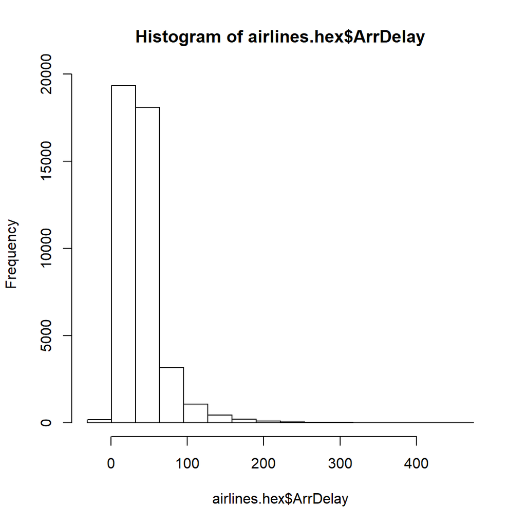

```r
h2o.hist(airlines.hex$ArrDelay)                  # 히스토그램 출력
```

```r
# airport별로 비행 횟수 출력
originFlights <- h2o.group_by(data = airlines.hex, by = "Origin", nrow("Origin")
                             , gb.control = list(na.methods = "rm"))
originFlights.R <- as.data.frame(originFlights)

head(originFlights.R)
```

```
##   Origin nrow
## 1    ABE   59
## 2    ABQ  876
## 3    ACY   31
## 4    ALB   75
## 5    AMA   11
## 6    ANC    1
```

```r
# 월별 비행 횟수 출력
flightsByMonth <- h2o.group_by(data = airlines.hex, by = "Month", nrow("Month"),
                              gb.control = list(na.methods = "rm"))
flightsByMonth.R <- as.data.frame(flightsByMonth)

head(flightsByMonth.R)
```

```
##   Month  nrow
## 1     1 41979
## 2    10  1999
```

```r
# 월별 비행 취소 횟수 출력
which(colnames(airlines.hex) == "Cancelled")
```

```
## [1] 22
```

```r
cancellationsByMonth <- h2o.group_by(data = airlines.hex, by = "Month", sum("Cancelled"),
                                     gb.control = list(na.methods = "rm"))
cancellationsByMonth.R <- as.data.frame(cancellationsByMonth)
head(cancellationsByMonth.R)
```

```
##   Month sum_Cancelled
## 1     1          1067
## 2    10            19
```

```r
# 월별 비행 취소율
cancellation_rate = cancellationsByMonth$sum_Cancelled/flightsByMonth$nrow
cancellation_rate
```

```
##   sum_Cancelled
## 1   0.025417471
## 2   0.009504752
##
## [2 rows x 1 column]
```

```r
rates_table = h2o.cbind(flightsByMonth$Month, cancellation_rate)
rates_table.R = as.data.frame(rates_table)

# training 과 test set으로 나누기 위해 데이터 쪼개기
airlines.split = h2o.splitFrame(data = airlines.hex, ratios = 0.85)

airlines.train <- airlines.split[[1]]
airlines.test <- airlines.split[[2]]

h2o.table(airlines.train$Cancelled)
```

```
##   Cancelled Count
## 1         0 36388
## 2         1   931
##
## [2 rows x 2 columns]
```

```r
h2o.table(airlines.test$Cancelled)
```

```
##   Cancelled Count
## 1         0  6504
## 2         1   155
##
## [2 rows x 2 columns]
```

```r
# GLM 시작
Y <- "IsDepDelayed"
X <- c("Origin", "Dest", "DayofMonth", "Year", "UniqueCarrier", "DayOfWeek", "Month",
       "DepTime","ArrTime", "Distance")

airlines.glm <- h2o.glm(training_frame = airlines.train, x = X, y = Y,
                        family = "binomial", alpha = 0.5)
# family : 종속변수의 분포함수

summary(airlines.glm)
```

```
## Model Details:
## ==============
##
## H2OBinomialModel: glm
## Model Key:  GLM_model_R_1542760329630_3
## GLM Model: summary
##     family  link                                regularization
## 1 binomial logit Elastic Net (alpha = 0.5, lambda = 1.459E-4 )
##   number_of_predictors_total number_of_active_predictors
## 1                        283                         179
##   number_of_iterations   training_frame
## 1                    6 RTMP_sid_878d_10
##
## H2OBinomialMetrics: glm
## ** Reported on training data. **
##
## MSE:  0.2144747
## RMSE:  0.4631142
## LogLoss:  0.6178426
## Mean Per-Class Error:  0.3925702
## AUC:  0.7168286
## Gini:  0.4336573
## R^2:  0.1399623
## Residual Deviance:  46114.54
## AIC:  46474.54
##
## Confusion Matrix (vertical: actual; across: predicted) for F1-optimal threshold:
##          NO   YES    Error          Rate
## NO     5574 12155 0.685600  =12155/17729
## YES    1950 17640 0.099541   =1950/19590
## Totals 7524 29795 0.377958  =14105/37319
##
## Maximum Metrics: Maximum metrics at their respective thresholds
##                         metric threshold    value idx
## 1                       max f1  0.370855 0.714387 282
## 2                       max f2  0.105242 0.846829 389
## 3                 max f0point5  0.541622 0.678749 187
## 4                 max accuracy  0.527162 0.658967 196
## 5                max precision  0.976852 1.000000   0
## 6                   max recall  0.051882 1.000000 399
```

[output cut: 31 more lines]

```
##              names coefficients sign
## 1       Origin.MDW     1.703782  POS
## 2       Origin.AUS     1.405491  NEG
## 3       Origin.HNL     1.336558  NEG
## 4       Origin.MYR     1.144184  NEG
## 5 UniqueCarrier.WN     1.112114  POS
##
## ---
##                names coefficients sign
## 279       Origin.TYS     0.000000  POS
## 280       Origin.UCA     0.000000  POS
## 281 UniqueCarrier.AA     0.000000  POS
## 282 UniqueCarrier.CO     0.000000  POS
## 283 UniqueCarrier.PI     0.000000  POS
## 284                            NA   NA
```

```r
# Predict
pred <- h2o.predict(object = airlines.glm, newdata = airlines.test)
summary(pred)
```

```
##  predict   NO                YES
##  YES:5307  Min.   :0.03164   Min.   :0.05146
##  NO :1352  1st Qu.:0.34522   1st Qu.:0.39988
##            Median :0.46809   Median :0.53100
##            Mean   :0.47561   Mean   :0.52439
##            3rd Qu.:0.59920   3rd Qu.:0.65386
##            Max.   :0.94854   Max.   :0.96836
```

## 3. Data Manipulation in R

### 3.1 Importing & uploading Files

`h2o.importFile` function : h2o.importFile(path = path, destination_frame = name)  
* `path` : data 경로  
* `destination_frame` : R에서 사용될 데이터 이름

```r
irisPath <- system.file("extdata", "iris.csv", package = "h2o")  # irisfile의 경로 지정
iris.hex <- h2o.importFile(path = irisPath, destination_frame = "iris.hex") # 데이터 불러오기
summary(iris.hex)
```

```
##  C1              C2              C3              C4
##  Min.   :4.300   Min.   :2.000   Min.   :1.000   Min.   :0.1000
##  1st Qu.:5.099   1st Qu.:2.799   1st Qu.:1.596   1st Qu.:0.2992
##  Median :5.798   Median :2.998   Median :4.348   Median :1.3000
##  Mean   :5.843   Mean   :3.054   Mean   :3.759   Mean   :1.1987
##  3rd Qu.:6.399   3rd Qu.:3.298   3rd Qu.:5.095   3rd Qu.:1.7992
##  Max.   :7.900   Max.   :4.400   Max.   :6.900   Max.   :2.5000
##  C5
##  Iris-setosa    :50
##  Iris-versicolor:50
##  Iris-virginica :50
##
##
##
```

- 데이터 경로는 IP주소로 HDFS 에서 불러오는 것도 가능하다.

H2O cluster에 파일 업로드  
`h2o.uploadFile` function : h2o.uploadFile(path = path, destination_frame = name)  
* `path` : 내보낼 파일 경로  
* `destination_frame` : 내보낼 파일이름.확장자

```r
irisPath <- system.file("extdata", "iris.csv", package = "h2o")  # irisfile의 경로 지정
iris.hex <- h2o.uploadFile(path = irisPath, destination_frame = "iris.hex") # 데이터 업로드
```

### 3.2 Finding & Converting Factors

범주형인 변수를 찾거나 변환하기

`h2o.anyFactor` function : h2o.anyfunction(data)  
* data 안에 factor인 변수가 있는지 확인하는 함수

`as.factor` function : as.factor(vector)  
* 벡터인 변수를 factor형으로 바꾸는 함수

```r
irisPath <- system.file("extdata", "iris_wheader.csv", package = "h2o")
iris.hex <- h2o.importFile(path = irisPath)
h2o.anyFactor(iris.hex)              # 데이터 안에 factor형 변수가 있는지 확인
```

```
## [1] TRUE
```

```r
str(iris.hex)
```

```
## Class 'H2OFrame' <environment: 0x00000000192942d0>
##  - attr(*, "op")= chr "Parse"
##  - attr(*, "id")= chr "iris_wheader.hex_sid_878d_16"
##  - attr(*, "eval")= logi FALSE
##  - attr(*, "nrow")= int 150
##  - attr(*, "ncol")= int 5
##  - attr(*, "types")=List of 5
##   ..$ : chr "real"
##   ..$ : chr "real"
##   ..$ : chr "real"
##   ..$ : chr "real"
##   ..$ : chr "enum"
##  - attr(*, "data")='data.frame': 10 obs. of  5 variables:
##   ..$ sepal_len: num  5.1 4.9 4.7 4.6 5 5.4 4.6 5 4.4 4.9
##   ..$ sepal_wid: num  3.5 3 3.2 3.1 3.6 3.9 3.4 3.4 2.9 3.1
##   ..$ petal_len: num  1.4 1.4 1.3 1.5 1.4 1.7 1.4 1.5 1.4 1.5
##   ..$ petal_wid: num  0.2 0.2 0.2 0.2 0.2 0.4 0.3 0.2 0.2 0.1
##   ..$ class    : Factor w/ 3 levels "Iris-setosa",..: 1 1 1 1 1 1 1 1 1 1
```

```r
prosPath <- system.file("extdata", "prostate.csv", package = "h2o")
prostate.hex <- h2o.importFile(path = prosPath)
as.factor(prostate.hex[,4])          # 변수 factor로 만들기
```

```
##   RACE
## 1    1
## 2    1
## 3    1
## 4    2
## 5    1
## 6    1
##
## [380 rows x 1 column]
```

```r
prostate.hex[,4] <- as.factor(prostate.hex[,4])
summary(prostate.hex[,4])            # 변수가 factor가 되어서 factor별로 counting 되었다.
```

```
##  RACE
##  1:341
##  2: 36
##  0:  3
```

### 3.3 Converting & Transferring Data Frames

Data Frame을 가공하거나 변환하기  
`as.h2o` function : as.h2o(data, destination_frame = name.hex)  
* `destination_frame` : h2o에 맞는 데이터 프레임 hex로 만든다.

```r
prosPath <- system.file("extdata", "prostate.csv", package = "h2o")
prostate.hex <- h2o.importFile(path = prosPath, destination_frame = "prostate.hex")
prostate.R <- as.data.frame(prostate.hex)    # hex data data frame으로 변환
summary(prostate.R)
```

```
##        ID            CAPSULE            AGE             RACE
##  Min.   :  1.00   Min.   :0.0000   Min.   :43.00   Min.   :0.000
##  1st Qu.: 95.75   1st Qu.:0.0000   1st Qu.:62.00   1st Qu.:1.000
##  Median :190.50   Median :0.0000   Median :67.00   Median :1.000
##  Mean   :190.50   Mean   :0.4026   Mean   :66.04   Mean   :1.087
##  3rd Qu.:285.25   3rd Qu.:1.0000   3rd Qu.:71.00   3rd Qu.:1.000
##  Max.   :380.00   Max.   :1.0000   Max.   :79.00   Max.   :2.000
##      DPROS           DCAPS            PSA              VOL
##  Min.   :1.000   Min.   :1.000   Min.   :  0.30   Min.   : 0.00
##  1st Qu.:1.000   1st Qu.:1.000   1st Qu.:  5.00   1st Qu.: 0.00
##  Median :2.000   Median :1.000   Median :  8.75   Median :14.25
##  Mean   :2.271   Mean   :1.108   Mean   : 15.41   Mean   :15.81
##  3rd Qu.:3.000   3rd Qu.:1.000   3rd Qu.: 17.12   3rd Qu.:26.45
##  Max.   :4.000   Max.   :2.000   Max.   :139.70   Max.   :97.60
##     GLEASON
##  Min.   :0.000
##  1st Qu.:6.000
##  Median :6.000
##  Mean   :6.384
##  3rd Qu.:7.000
##  Max.   :9.000
```

```r
iris.hex <- as.h2o(iris, destination_frame = "iris.hex") # data frame을 h2o frame으로 변환
```

- `extdata`는 패키지 내부에 있는 데이터를 말한다. 별다른 경로가 필요하지 않으며 뒤에 `package =`만 쓰면 된다.

### 3.4 summarizig data & table

```r
h2o.ls()                                    # h2o 상에 올라와 있는 objet들의 list를 출력해준다.
```

```
##                                                                                                      key
## 1                                                                            GLM_model_R_1542760329630_3
## 2                                                                                       RTMP_sid_878d_10
## 3                                                                                       RTMP_sid_878d_13
## 4                                                                                        RTMP_sid_878d_5
## 5                                                                                        RTMP_sid_878d_6
## 6                                                                                        RTMP_sid_878d_7
## 7                                                                                        RTMP_sid_878d_8
## 8                                                                                        RTMP_sid_878d_9
## 9                                                                                           airlines.hex
## 10                                                                                              iris.hex
## 11                                                                          iris_wheader.hex_sid_878d_16
## 12 modelmetrics_GLM_model_R_1542760329630_3@6806974990659189040_on_RTMP_sid_878d_10@-2327875491256207614
## 13  modelmetrics_GLM_model_R_1542760329630_3@6806974990659189040_on_RTMP_sid_878d_13@2321441504501371614
## 14                                      predictions_9528_GLM_model_R_1542760329630_3_on_RTMP_sid_878d_13
## 15                                                                                          prostate.hex
## 16                                                                              prostate.hex_sid_878d_17
```

```r
h2o.table(prostate.hex[,c("AGE","RACE")])   # data의 변수에 따른 count를 보여줌
```

```
##   AGE RACE Counts
## 1  43    0      1
## 2  47    1      1
## 3  50    1      2
## 4  51    1      3
## 5  52    1      2
## 6  53    1      3
##
## [53 rows x 3 columns]
```

### 3.5 Generating Random Numbers

훈련데이터랑 테스트 데이터를 나누는 방법은 두가지가 있다.

`h2o.runif` function : h2o.runif(data)  
* 데이터에서 uniform 분포에 따라 random number 추출

`h2o.splitFrame` function : h2o.splitFrame(data, ratios = rate)  
* `data` : 쪼갤 data 입력  
* `ratios` : 얼만큼의 비율로 쪼갤건지 설정. 벡터를 이용해 여러개로 쪼갤 수 도 있음

```r
### 1. h2o.runif()를 이용한 training set, test set 만들기
s <- h2o.runif(prostate.hex)          # prostate 데이터에서 uniform 분포의 random 변수 생성.
summary(s)
```

```
##  rnd
##  Min.   :0.003388
##  1st Qu.:0.245813
##  Median :0.475308
##  Mean   :0.490756
##  3rd Qu.:0.751299
##  Max.   :0.997950
```

```r
prostate.train <- prostate.hex[s <= 0.8,]                      # 80%의 training set 생성
prostate.train <- h2o.assign(prostate.train, "prostate.train") # cluster에 assign
prostate.test <- prostate.hex[s > 0.8,]                        # 20%의 test set 생성
prostate.test <- h2o.assign(prostate.test, "prostate.test")    # cluster에 assign

nrow(prostate.train) + nrow(prostate.test)                     # 데이터의 행의 개수 확인
```

```
## [1] 380
```

```r
nrow(prostate.hex)
```

```
## [1] 380
```

```r
### 2. h2o.splitFrame()를 이용한 training set, test set 만들기
prostate.split <- h2o.splitFrame(data = prostate.hex, ratios = 0.75) # 0.75를 기준으로 데이터를 분리함.
prostate.train <- prostate.split[[1]]                          # training set
prostate.test <- prostate.split[[2]]                           # test set
```

### 3.6 Getting Frames & Models

`h2o.getFrame()` : h2o cluster에 있는 data frame 불러오기  
`h2o.getModel()` : h2o cluster에 있는 Model 불러오기

```r
# prostate.hex <- h2o.getFrame(id = "prostate.hex_sid_85ce_21") # h2o cluster에서 데이터 불러오기
# prostate.hex

# gbm.model <- h2o.getModel(model_id = "GBM_8e4591a9b413407b983d73fbd9eb44cf")
# model 불러오기

h2o.rm("prostate.train")              # cluster에 올라와 있는 데이터 지우기
h2o.ls()
```

```
##                                                                                                      key
## 1                                                                            GLM_model_R_1542760329630_3
## 2                                                                                       RTMP_sid_878d_10
## 3                                                                                       RTMP_sid_878d_13
## 4                                                                                       RTMP_sid_878d_23
## 5                                                                                        RTMP_sid_878d_5
## 6                                                                                        RTMP_sid_878d_6
## 7                                                                                        RTMP_sid_878d_7
## 8                                                                                        RTMP_sid_878d_8
## 9                                                                                        RTMP_sid_878d_9
## 10                                                                                          airlines.hex
## 11                                                                                              iris.hex
## 12                                                                          iris_wheader.hex_sid_878d_16
## 13 modelmetrics_GLM_model_R_1542760329630_3@6806974990659189040_on_RTMP_sid_878d_10@-2327875491256207614
## 14  modelmetrics_GLM_model_R_1542760329630_3@6806974990659189040_on_RTMP_sid_878d_13@2321441504501371614
## 15                                      predictions_9528_GLM_model_R_1542760329630_3_on_RTMP_sid_878d_13
## 16                                                                                          prostate.hex
## 17                                                                              prostate.hex_sid_878d_17
## 18                                                                                         prostate.test
```

```r
h2o.removeAll()                      # cluster에 있는 모든 데이터 제거
```

```
## [1] 0
```

## 4. Running Models

### 4.1 Gradient Boosting Machine (GBM)

GBM은 앙상블 러닝에서 모형을 향상시켜주는데 사용된다.  
`h2o.gbm` function : h2o.gbm(y, x, training_frame, ntrees, max_depth, min_rows,  
learn_rate, distribution)  
* `y` : 종속변수  
* `x` : 독립변수  
* `training_frame` : 훈련데이터  
* `ntrees` : 나무의 가지수. default는 50  
* `max_depth` : 나무의 최대 높이. default는 5  
* `min_rows` : leaf node에 주는 가중치의 최소값 default는 10  
* `learn_rate` : learning rate. default는 0.1  
* `distribution` : 분포 결정.  
* 이 밖에도 여러가지 option이 있음.

Model detail, training data의 MSE, Scoring History, 등을 알 수 있다.

```r
data(iris)
iris.hex <- as.h2o(iris, destination_frame = "iris.hex")
# 설명변수가 연속형일 때
iris.gbm <- h2o.gbm(y = 1, x = 2:5, training_frame = iris.hex, ntrees = 10,
                    max_depth = 3, min_rows = 2, learn_rate = 0.2, distribution = "gaussian")
summary(iris.gbm)   # model의 결과 & 정확도 출력
```

```
## Model Details:
## ==============
##
## H2ORegressionModel: gbm
## Model Key:  GBM_model_R_1542760329630_6
## Model Summary:
##   number_of_trees number_of_internal_trees model_size_in_bytes min_depth
## 1              10                       10                1593         3
##   max_depth mean_depth min_leaves max_leaves mean_leaves
## 1         3    3.00000          7          8     7.80000
##
## H2ORegressionMetrics: gbm
## ** Reported on training data. **
##
## MSE:  0.07071353
## RMSE:  0.2659202
## MAE:  0.2204892
## RMSLE:  0.03919705
## Mean Residual Deviance :  0.07071353
##
##
##
##
##
## Scoring History:
##              timestamp   duration number_of_trees training_rmse
## 1  2018-11-21 09:32:56  0.043 sec               0       0.82530
## 2  2018-11-21 09:32:56  0.380 sec               1       0.68743
## 3  2018-11-21 09:32:56  0.453 sec               2       0.57874
## 4  2018-11-21 09:32:56  0.517 sec               3       0.49286
## 5  2018-11-21 09:32:57  0.577 sec               4       0.42911
## 6  2018-11-21 09:32:57  0.601 sec               5       0.37899
## 7  2018-11-21 09:32:57  0.618 sec               6       0.34171
## 8  2018-11-21 09:32:57  0.628 sec               7       0.31489
## 9  2018-11-21 09:32:57  0.646 sec               8       0.29409
## 10 2018-11-21 09:32:57  0.659 sec               9       0.27859
## 11 2018-11-21 09:32:57  0.674 sec              10       0.26592
##    training_mae training_deviance
## 1       0.68756           0.68112
## 2       0.56951           0.47256
## 3       0.47906           0.33494
## 4       0.40782           0.24291
## 5       0.35389           0.18414
## 6       0.31358           0.14363
## 7       0.28382           0.11677
## 8       0.26233           0.09916
## 9       0.24280           0.08649
## 10      0.23115           0.07761
## 11      0.22049           0.07071
##
## Variable Importances: (Extract with `h2o.varimp`)
## =================================================
##
## Variable Importances:
##       variable relative_importance scaled_importance percentage
## 1 Petal.Length          227.732895          1.000000   0.895398
## 2  Sepal.Width           14.987644          0.065812   0.058928
## 3      Species            9.515450          0.041783   0.037413
## 4  Petal.Width            2.100992          0.009226   0.008261
```

```r
iris.gbm@model$scoring_history # tree의 수에 따른 rmse, mae, 분산출력
```

```
## Scoring History:
##              timestamp   duration number_of_trees training_rmse
## 1  2018-11-21 09:32:56  0.043 sec               0       0.82530
## 2  2018-11-21 09:32:56  0.380 sec               1       0.68743
## 3  2018-11-21 09:32:56  0.453 sec               2       0.57874
## 4  2018-11-21 09:32:56  0.517 sec               3       0.49286
## 5  2018-11-21 09:32:57  0.577 sec               4       0.42911
## 6  2018-11-21 09:32:57  0.601 sec               5       0.37899
## 7  2018-11-21 09:32:57  0.618 sec               6       0.34171
## 8  2018-11-21 09:32:57  0.628 sec               7       0.31489
## 9  2018-11-21 09:32:57  0.646 sec               8       0.29409
## 10 2018-11-21 09:32:57  0.659 sec               9       0.27859
## 11 2018-11-21 09:32:57  0.674 sec              10       0.26592
##    training_mae training_deviance
## 1       0.68756           0.68112
## 2       0.56951           0.47256
## 3       0.47906           0.33494
## 4       0.40782           0.24291
## 5       0.35389           0.18414
## 6       0.31358           0.14363
## 7       0.28382           0.11677
## 8       0.26233           0.09916
## 9       0.24280           0.08649
## 10      0.23115           0.07761
## 11      0.22049           0.07071
```

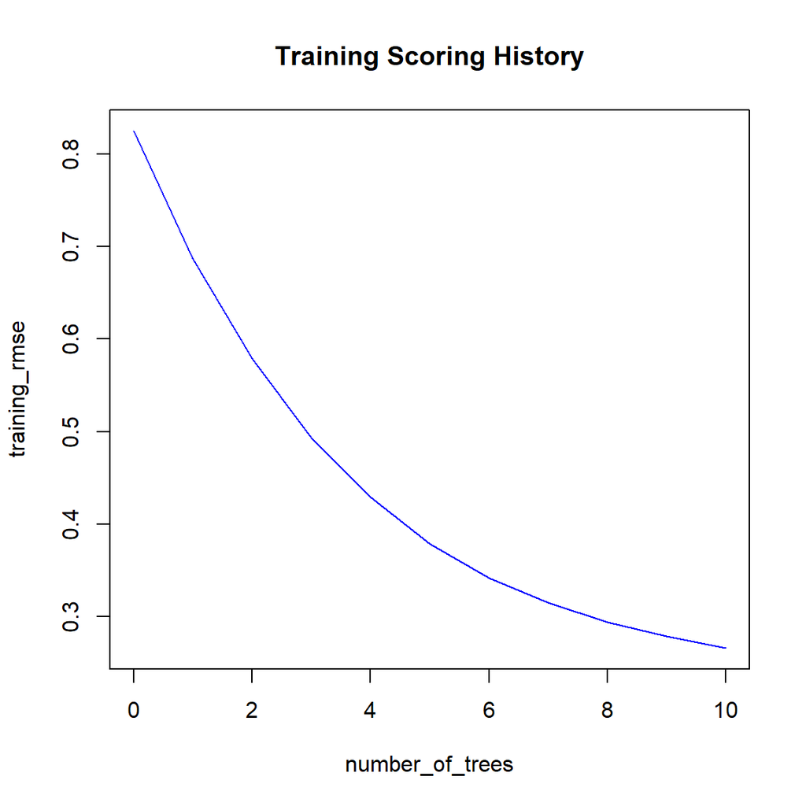

```r
plot(iris.gbm)                 # tree의 수에 따른 error 그래프 출력
```

```r
# 설명변수가 범주형일 때
iris.gbm2 <- h2o.gbm(y = 5, x = 1:4, training_frame = iris.hex, ntrees = 15,
                     max_depth = 5, min_rows = 2, learn_rate = 0.01,
                     distribution = "multinomial")
iris.gbm2@model$training_metrics
```

```
## H2OMultinomialMetrics: gbm
## ** Reported on training data. **
##
## Training Set Metrics:
## =====================
##
## Extract training frame with `h2o.getFrame("iris.hex")`
## MSE: (Extract with `h2o.mse`) 0.3293958
## RMSE: (Extract with `h2o.rmse`) 0.5739301
## Logloss: (Extract with `h2o.logloss`) 0.8533637
## Mean Per-Class Error: 0.01333333
## Confusion Matrix: Extract with `h2o.confusionMatrix(<model>,train = TRUE)`)
## =========================================================================
## Confusion Matrix: Row labels: Actual class; Column labels: Predicted class
##            setosa versicolor virginica  Error      Rate
## setosa         50          0         0 0.0000 =  0 / 50
## versicolor      0         49         1 0.0200 =  1 / 50
## virginica       0          1        49 0.0200 =  1 / 50
## Totals         50         50        50 0.0133 = 2 / 150
##
## Hit Ratio Table: Extract with `h2o.hit_ratio_table(<model>,train = TRUE)`
## =======================================================================
## Top-3 Hit Ratios:
##   k hit_ratio
## 1 1  0.986667
## 2 2  1.000000
## 3 3  1.000000
```

### 4.2 Generalized Linear Models (GLM)

일반화 선형모델을 말하는 것으로 종속변수가 범주형이거나, 이산형일 경우 사용한다.  
보통 distribution으로 exponential 함수나 Gaussian 함수를 사용한다.  
H2O에서는 일반화하는 과정을 elastic net penalty를 사용한다.

`hlo.gbm` function : h2o.glm(y, x, training_frame, family, nfolds, alpha)  
* `y` : 종속변수  
* `x` : 독립변수  
* `training_frame` : 훈련데이터  
* `family` : 종속변수의 분포를 정의  
* `nfold` : K-fold 교차검정을 하는 횟수를 정의.  
* `alpha` : L1(LASSO)와 L2(Ridge)사이의 값 지정, 1일 경우 L1을 선택, 0일 경우 L2를 선택한다. 그 중간은 Elastic 이라 부른다.  
* 이 밖에도 여러가지 option이 있음.

결과창으로는 MSE, AUC(과적합 판단), R^2(결정계수), Confusion Matrix 등을 보여준다.

```r
prostate.hex <- h2o.importFile(path = "https://raw.github.com/h2oai/h2o/master/smalldata/logreg/prostate.csv",
                               destination_frame = "prostate.hex")
prostate.glm <- h2o.glm(y = "CAPSULE", x = c("AGE", "RACE", "PSA", "DCAPS"), training_frame = prostate.hex,
                        family = "binomial", nfolds = 10, alpha = 0.5)
summary(prostate.glm)                                   # 성능 및 정확도에 대해 보여주고 있다.
```

```
## Model Details:
## ==============
##
## H2OBinomialModel: glm
## Model Key:  GLM_model_R_1542760329630_8
## GLM Model: summary
##     family  link                                regularization
## 1 binomial logit Elastic Net (alpha = 0.5, lambda = 3.247E-4 )
##   number_of_predictors_total number_of_active_predictors
## 1                          4                           4
##   number_of_iterations training_frame
## 1                    4   prostate.hex
##
## H2OBinomialMetrics: glm
## ** Reported on training data. **
##
## MSE:  0.2027036
## RMSE:  0.4502261
## LogLoss:  0.5914634
## Mean Per-Class Error:  0.3826121
## AUC:  0.717601
## Gini:  0.435202
## R^2:  0.1572256
## Residual Deviance:  449.5122
## AIC:  459.5122
##
## Confusion Matrix (vertical: actual; across: predicted) for F1-optimal threshold:
##         0   1    Error      Rate
## 0      80 147 0.647577  =147/227
## 1      18 135 0.117647   =18/153
## Totals 98 282 0.434211  =165/380
##
## Maximum Metrics: Maximum metrics at their respective thresholds
##                         metric threshold    value idx
## 1                       max f1  0.284048 0.620690 274
## 2                       max f2  0.207093 0.778230 360
## 3                 max f0point5  0.413268 0.636672 108
## 4                 max accuracy  0.413268 0.705263 108
## 5                max precision  0.998478 1.000000   0
## 6                   max recall  0.207093 1.000000 360
```

[output cut: 93 more lines]

```
## 2   0.59762
## 3   0.59205
## 4   0.59181
## 5   0.59181
##
## Variable Importances: (Extract with `h2o.varimp`)
## =================================================
##
## Standardized Coefficient Magnitudes: standardized coefficient magnitudes
##   names coefficients sign
## 1   PSA     0.937727  POS
## 2 DCAPS     0.408386  POS
## 3  RACE     0.192433  NEG
## 4   AGE     0.071648  NEG
## 5                 NA   NA
```

```r
prostate.glm@model$cross_validation_metrics
```

```
## H2OBinomialMetrics: glm
## ** Reported on cross-validation data. **
## ** 10-fold cross-validation on training data (Metrics computed for combined holdout predictions) **
##
## MSE:  0.208858
## RMSE:  0.4570099
## LogLoss:  0.6080366
## Mean Per-Class Error:  0.4258156
## AUC:  0.6874118
## Gini:  0.3748236
## R^2:  0.1316375
## Residual Deviance:  462.1078
## AIC:  472.1078
##
## Confusion Matrix (vertical: actual; across: predicted) for F1-optimal threshold:
##         0   1    Error      Rate
## 0      50 177 0.779736  =177/227
## 1      11 142 0.071895   =11/153
## Totals 61 319 0.494737  =188/380
##
## Maximum Metrics: Maximum metrics at their respective thresholds
##                         metric threshold    value idx
## 1                       max f1  0.266859 0.601695 307
## 2                       max f2  0.161721 0.773509 365
## 3                 max f0point5  0.419489 0.619546 104
## 4                 max accuracy  0.419489 0.694737 104
## 5                max precision  0.997940 1.000000   0
## 6                   max recall  0.161721 1.000000 365
## 7              max specificity  0.997940 1.000000   0
## 8             max absolute_mcc  0.638042 0.355018  55
## 9   max min_per_class_accuracy  0.330141 0.640523 177
## 10 max mean_per_class_accuracy  0.419489 0.657136 104
##
## Gains/Lift Table: Extract with `h2o.gainsLift(<model>, <data>)` or `h2o.gainsLift(<model>, valid=<T/F>, xval=<T/F>)`
```

### 4.3 K-means

`h2o.kmeans` function : h2o.kmeans(training_frame, k, x)  
* training_frame : 학습할 데이터  
* k : k의 개수  
* x : 입력될 데이터 변수

Centroid Statistics 가 출력된다.

```r
h2o.kmeans(training_frame = iris.hex, k = 3, x = 1:4)
```

```
## Model Details:
## ==============
##
## H2OClusteringModel: kmeans
## Model ID:  KMeans_model_R_1542760329630_41
## Model Summary:
##   number_of_rows number_of_clusters number_of_categorical_columns
## 1            150                  3                             0
##   number_of_iterations within_cluster_sum_of_squares total_sum_of_squares
## 1                    6                     139.14814            596.00000
##   between_cluster_sum_of_squares
## 1                      456.85186
##
##
## H2OClusteringMetrics: kmeans
## ** Reported on training data. **
##
##
## Total Within SS:  139.1481
## Between SS:  456.8519
## Total SS:  596
## Centroid Statistics:
##   centroid     size within_cluster_sum_of_squares
## 1        1 51.00000                      53.08639
## 2        2 50.00000                      47.35062
## 3        3 49.00000                      38.71113
```

### 4.4 Principal Components Analysis(PCA)

h2o에서는 주성분분석도 지원해준다.  
`h2o.prcomp` function : h2o.prcomp(training_frame, transform, k)  
* `training_frame` : 학습데이터 입력  
* `transform` : training data를 어떻게 변환할건지 정의.  
* `k` : PCA 주성분의 숫자 지정

```r
ausPath <- system.file("extdata", "australia.csv", package = "h2o")
australia.hex <- h2o.importFile(path = ausPath)
australia.pca <- h2o.prcomp(training_frame = australia.hex, transform = "STANDARDIZE", k = 3)
australia.pca
```

```
## Model Details:
## ==============
##
## H2ODimReductionModel: pca
## Model ID:  PCA_model_R_1542760329630_42
## Importance of components:
##                             pc1      pc2      pc3
## Standard deviation     1.750703 1.512142 1.031181
## Proportion of Variance 0.383120 0.285822 0.132917
## Cumulative Proportion  0.383120 0.668942 0.801859
##
##
## H2ODimReductionMetrics: pca
##
## No model metrics available for PCA
```

### 4.5 Predictions

우리가 예측을 할때 확인해야 할 것은 아래와 같다.  
* predict : 모델을 돌린 후 나오는 예측값들.  
* Confusion Matrix : 알고리즘 후 예측값과 실제값들에 대한 table  
* AUC Curve : 민감도와 관련된 Curve로 값이 클 수록 적합하다고 할 수 있음  
* PCA Score : 주성분분석을 했을 때 나오는 값으로 보통 0.85 까지 오면 주성분의 개수를 멈춤.

```r
prostate.fit <- h2o.predict(object = prostate.glm, newdata = prostate.hex)
prostate.fit
```

```
##   predict        p0        p1
## 1       0 0.7447685 0.2552315
## 2       1 0.3976236 0.6023764
## 3       1 0.4126733 0.5873267
## 4       1 0.3727686 0.6272314
## 5       1 0.6464995 0.3535005
## 6       1 0.4336632 0.5663368
##
## [380 rows x 3 columns]
```

참고 : Machine Learning with R and H2O (http://h2o.ai/resources/)